# Indicadores de Riesgos de Corrupcion

Investigación Doctoral

Heriberto Felizzola

# 1 Limpiar Datos

```r
# Cargar datos
contratos <- vroom("Datos/secop_i_ips_limpia.csv.gz",
                   col_select = c("nombre_entidad", "tipo_proceso", "tipo_contrato",
                                  "cuantia_contrato","id_contratista",
                                  "objeto_contratar", "detalle_objeto_contratar",
                                  "ruta_web"))
```

```
Rows: 1,391,442
Columns: 8
chr [7]: nombre_entidad, tipo_proceso, objeto_contratar, detalle_objeto_contratar, tipo_contrato, id_...
dbl [1]: cuantia_contrato

Pass a specification to the `col_types` argument to quiet this message
```

Se aplica el siguiente filtro:

- Contratos de mas de 10 millones.
- Entidades con mínimo 3 contratos

```r
# Quitar contratos de prestación de servicios
contratos <- contratos %>%
  filter(cuantia_contrato >= 1e7)

# Consultar las entidades con menos de 10 contratos
entidades_del <- contratos %>%
  group_by(nombre_entidad) %>%
  summarise(contratos = n()) %>%
  filter(contratos < 3)
# Quitar las entidades con menos de 10 contratos
contratos <- contratos %>%
  filter(!(nombre_entidad %in% entidades_del$nombre_entidad))
```

# 2 Indicadores para la Falta de Competencia

## 2.1 Porcentaje de procedimientos que utilizaron adjudicación directa

Mide el porcentaje de contratos que la entidad realiza bajo la modalidad de contratación directa. Este porcentaje se puede calcular con respecto al numero de contratos o al valor de los contratos:

$$\text{Contratación Directa} = \frac{\text{Cantidad de Contratación Directa de la Entidad}}{\text{Total de Contratación de la Entidad}} \times 100$$
Donde,

- La *cantidad de contratación directa* puede ser: el numero de contratos o el valor total contratación ejecutado por la entidad bajo esta modalidad.
- El *total de la contratación* puede ser: el numero de contratos total o el valor total de la contratación de cada entidad.

```r
# Calcula el porcentaje de contratación en numero de contratos
indicadores <- contratos %>%
  group_by(nombre_entidad) %>%
  summarise(perc_contr_directa_num = sum((tipo_proceso == "Contratación Directa (Ley 1150 de 2007)")/n())*100)
```

```r
# Calcula el porcentaje de contratación con respecto al valor de los contratos
temp <- contratos %>%
  group_by(nombre_entidad, tipo_proceso) %>%
  summarise(valor_contratos = sum(cuantia_contrato)) %>%
  group_by(nombre_entidad) %>%
  mutate(valor_total = sum(valor_contratos),
         perc_valor = (valor_contratos/valor_total)*100) %>%
  filter(tipo_proceso == "Contratación Directa (Ley 1150 de 2007)") %>%
  rename(perc_contr_direct_val = "perc_valor") %>%
  select(nombre_entidad, perc_contr_direct_val)
```

```r
# Agrupar los indicadores en una sola tabla
indicadores <- indicadores %>%
  left_join(y = temp, by = "nombre_entidad") %>%
  mutate(perc_contr_direct_val = ifelse(is.na(perc_contr_direct_val), 0, perc_contr_direct_val))
rm(temp)
```

## 2.2 Indice de concentración de contratos HHI

El índice *Herfindahl*, también conocido como Índice *Herfindahl-Hirschman* o *HHI*, es una medida del tamaño de las empresas en relación con la industria y un indicador de la cantidad de competencia entre ellas. Se calcula como la suma de los cuadrados de las cuotas de mercado de las empresas dentro de la industria (a veces limitada a las 50 empresas más grandes).

$$HHI = \sum_{i=1}^{n}s_{i}^2$$
Donde, $s_i$ es la cuota de mercado de la empresa $i$ expresada en porcentaje. Tiendo en cuenta que el indicador esta en un rango de [0,10000], se estandariza el indicador dividiendo el HHI entre 10000.

$$HHI^{STD} = \frac{HHI}{10000} \times 100$$

```r
temp <- contratos %>%
  group_by(nombre_entidad, id_contratista) %>%
  summarise(cant_contratos = n(),
            val_contratos = sum(cuantia_contrato)) %>%
  group_by(nombre_entidad) %>%
  mutate(total_contratos_ent = sum(cant_contratos),
         total_val_contratos_ent = sum(val_contratos),
         si_cant = (cant_contratos/total_contratos_ent)*100,
         si2_cant = si_cant^2,
         si_val = (val_contratos/total_val_contratos_ent)*100,
         si2_val = si_val^2) %>%
  group_by(nombre_entidad) %>%
  summarise(HHI_cant = (sum(si2_cant)/10000)*100,
            HHI_val = (sum(si2_val)/10000)*100)
```

```r
# Agrupar los indicadores en una sola tabla
indicadores <- indicadores %>%
  left_join(y = temp, by = "nombre_entidad")
rm(temp)
```

## 2.3 Indice de diversidad - ID

El *indice de diversidad de Simpson* (también conocido como el índice de la diversidad de las especies o índice de dominancia) es uno de los parámetros que permiten medir la biodiversidad de organismos en un hábitat. Llevado al contexto de la contratación permite medir la diversidad de contratistas en una entidad. La formula para el indice de Simpson es:

$$ID = \frac{\sum_{j=1}^{S} n_j (n_j - 1)}{N (N - 1)}$$
Donde,

- $S$: Numero total de contratistas de una entidad.
- $n_j$: es el numero o valor total de contratos adjudicados al contratista $j$.
- $N$: es el numero o valor total de los contratos adjudicados por cada entidad.

Cuando el indice es cercano a 1 existe una menor diversidad y por tanto mayor dominancia de algunos contratistas, y cuando es cercano a 0 ocurre lo contrario, existe mayor diversidad y por tanto menor dominancia de algunos contratistas.

```r
# Calcula el indice de diversidad de Simpson
temp <- contratos %>%
  group_by(nombre_entidad, id_contratista) %>%
  summarise(nj_cant = n(),
            nj_val = sum(cuantia_contrato),
            sub_cant = nj_cant*(nj_cant - 1),
            sub_val = nj_val*(nj_val - 1)) %>%
  group_by(nombre_entidad) %>%
  summarise(N_cant = sum(nj_cant),
         N_val = sum(nj_val),
         ID_cant = (sum(sub_cant)/(N_cant*(N_cant - 1))*100),
         ID_val = (sum(sub_val)/(N_val*(N_val - 1)))*100) %>%
  select(nombre_entidad, ID_cant, ID_val)
```

```r
# Agrupar los indicadores en una sola tabla
indicadores <- indicadores %>%
  left_join(y = temp, by = "nombre_entidad")
rm(temp)
```

## 2.4 Número de empresas ganadoras diferentes por cada 100 contratos

Mide el número de empresas diferentes adjudicatarias de los procesos de contratación. Dado que cada entidad tiene un volumen diferente de contratación, el indice se expresó en numero de contratistas por cada 100 contratos.

$$\text{Empresas Ganadoras} = \frac{\text{# Contratistas Diferentes}}{\text{# Contratos}} \times 100$$
Dado que una mayor cantidad de empresas ganadoras representa un menor riesgo de corrupción, se hace una conversión de la siguiente manera:

$$\text{Empresas Ganadoras}^{STD} = 100 - \text{Empresas Ganadoras}$$

```r
# Calcular el indicador de diversidad
temp <- contratos %>%
  group_by(nombre_entidad) %>%
  summarise(n_contratistas_dif = n_distinct(id_contratista),
            n_contratos = n(),
            ganadoras = (n_contratistas_dif/n_contratos)*100) %>%
  mutate(ganadoras = 100-ganadoras) %>%
  select(nombre_entidad, ganadoras)
```

```r
# Agrupar los indicadores en una sola tabla
indicadores <- indicadores %>%
  left_join(y = temp, by = "nombre_entidad")
rm(temp)
```

## 2.5 Índice de concentración de las cuatro empresas con mayor numero y valor de contratos - IC4k

Mide el número de procesos que la entidad estatal adjudicó a los cuatro contratistas con más contratos. Un valor alto indicaría que hay pocos contratistas con muchos contratos.

$$IC4K = \frac{\sum_{k=1}^{K} n_k}{N}$$
Donde:

- $k$: representa la posición del k-esimo contratista en numero o valor de contratos.
- $K$: se tomaran los primeros 4 cuatro contratistas.
- $n_k$: es el numero o valor de los contratos del contratista $k$.
- $N$: es el numero o valor total de contratos de la entidad.

```r
# Indice para el numero de contratos
temp <- contratos %>%
  group_by(nombre_entidad, id_contratista) %>%
  summarise(nj = n()) %>%
  group_by(nombre_entidad) %>%
  mutate(Ni = sum(nj),
         Pi = nj/Ni) %>%
  top_n(n = 4, wt = nj) %>%
  summarise(IC4K_cant = sum(Pi)*100)
```

```r
# Agrupar los indicadores en una sola tabla
indicadores <- indicadores %>%
  left_join(y = temp, by = "nombre_entidad")
rm(temp)
```

```r
# Indice para el valor de los contratos
temp <- contratos %>%
  group_by(nombre_entidad, id_contratista) %>%
  summarise(nj = sum(cuantia_contrato)) %>%
  group_by(nombre_entidad) %>%
  mutate(Ni = sum(nj),
         Pi = nj/Ni) %>%
  top_n(n = 4, wt = nj) %>%
  summarise(IC4K_val = sum(Pi)*100)
```

```r
# Agrupar los indicadores en una sola tabla
indicadores <- indicadores %>%
  left_join(y = temp, by = "nombre_entidad")
rm(temp)
```

# 3 Indice de corrupción

```r
indicadores <- indicadores %>%
  rowwise() %>%
  mutate(ind_riesgo_corrupcion = mean(c_across(perc_contr_directa_num:ID_val)))
```

# 4 Resumen estadístico

A continuación se presenta un resumen estadístico que muestra el comportamiento estadístico y la distribución de cada uno de los indicadores de corrupción.

```r
indicadores %>%
  select(-nombre_entidad) %>%
  summary()
```

```
 perc_contr_directa_num perc_contr_direct_val    HHI_cant           HHI_val
 Min.   :  0.00         Min.   :  0.000       Min.   : 0.03094   Min.   : 0.4509
 1st Qu.:  0.00         1st Qu.:  0.000       1st Qu.: 1.21475   1st Qu.: 4.1464
 Median :  5.90         Median :  3.815       Median : 2.50364   Median : 8.3778
 Mean   : 31.82         Mean   : 29.128       Mean   : 4.41638   Mean   :14.6912
 3rd Qu.: 68.62         3rd Qu.: 60.895       3rd Qu.: 5.10108   3rd Qu.:16.7866
 Max.   :100.00         Max.   :100.000       Max.   :55.55556   Max.   :99.2421
    ID_cant            ID_val          ganadoras       IC4K_cant          IC4K_val
 Min.   : 0.0000   Min.   : 0.4509   Min.   : 0.00   Min.   :  1.235   Min.   :  7.633
 1st Qu.: 0.7691   1st Qu.: 4.1464   1st Qu.:35.50   1st Qu.: 14.758   1st Qu.: 31.815
 Median : 1.5064   Median : 8.3778   Median :46.22   Median : 24.855   Median : 46.338
 Mean   : 2.6915   Mean   :14.6912   Mean   :45.38   Mean   : 33.548   Mean   : 49.217
 3rd Qu.: 2.8986   3rd Qu.:16.7866   3rd Qu.:57.56   3rd Qu.: 42.586   3rd Qu.: 62.960
 Max.   :47.3582   Max.   :99.2421   Max.   :90.48   Max.   :100.000   Max.   :100.000
 ind_riesgo_corrupcion
 Min.   : 0.2403
 1st Qu.: 3.6130
 Median :10.9025
 Mean   :16.2401
 3rd Qu.:28.7089
 Max.   :66.6053
```

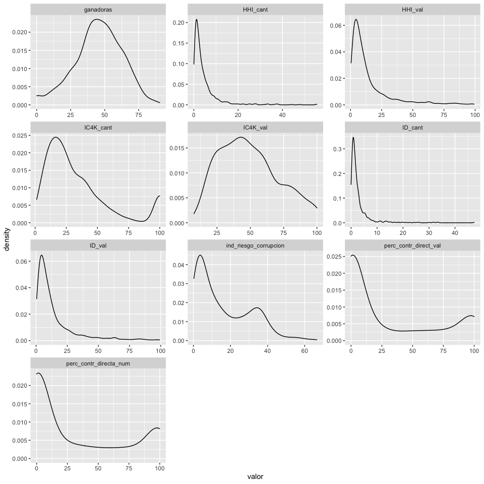

```r
indicadores %>%
  pivot_longer(cols = c(perc_contr_directa_num:ind_riesgo_corrupcion),
               names_to = "indicador",
               values_to = "valor") %>%
  ggplot(aes(x = valor)) +
  geom_density() +
  facet_wrap(vars(indicador), ncol = 3, scales = "free")
```

```r
vroom_write(indicadores, path = "Datos/indicadores-corrupcion.csv", delim = ";")
```